# Econometria Aplicada à Finanças Aula 5

Mestrado Profissional em Administração

Prof. Washington Santos da Silva

IFMG - Campus Formiga

16 de setembro de 2025

## Diário de Bordo

**O que vimos até o momento?**

- Aula 1 ✅
  - Apresentação da Disciplina ✅
  - Introdução ao RStudio ✅
  - Configurando o Projeto da Disciplina ✅
  - Conheça e Utilize o Terminal Git Bash ✅
- Aula 2 ✅
  - Git e GitHub: Visão Geral ✅
  - Introdução ao Sistema: Visão Geral ✅
  - Linguagem R: Visão Geral ✅
  - Sessão Prática 1 ✅
- Aula 3 ✅
  - Minicurso Intensivo: Teoria da Probabilidade - Parte 1 ✅
    - Introdução à Teoria da Probabilidade ✅
    - Variáveis Aleatórias e Distribuições de Probabilidade ✅
    - Distribuições Conjunta, Marginal e Condicional ✅
    - Independência de Variáveis Aleatórias ✅
- Aula 4 ✅
  - Minicurso Intensivo: Teoria da Probabilidade - Parte 2 ✅
    - Conceitos Básicos: Revisão
    - Momentos de Distribuições de Probabilidade Univariadas
    - Funções de Variáveis Aleatórias
    - Fundamentos de Distribuições de Probabilidade Multivariadas
    - Cálculo Diferencial e Integral em R

## Nesta Aula

**Minicurso Intensivo sobre Teoria da Probabilidade - Parte 3**

- Distribuições de Variáveis Aleatórias Discretas
- Distribuições de Variáveis Aleatórias Contínuas
- Distribuições de Vetores Aleatórios
- A Ponte entre Probabilidade e Estatística/Econometria

**Diretrizes para Aulas Mais Produtivas**

⌨️ **Código com método:**

95% dos erros são evitáveis com:

- Respeitar a sequência lógica de etapas
- Revisão antes de pedir ajuda
- Atenção na digitação

🤝 **Inteligência colaborativa:**

- Compartilhe conhecimento
- Resolva questões técnicas simples com colegas próximos
- Reserve ao professor as dúvidas conceituais complexas

💪 **Capacidade de Resolver Problemas**

Cada problema/erro resolvido é uma evolução da sua habilidade analítica

# Distribuicões de Probabilidade

## Introdução

**Origens de Distribuições de Probabilidade**

- Algumas distribuições são especiais porque podem ser usadas para **modelar uma ampla variedade de fenômenos aleatórios**:
  - Isso pode ocorrer devido a um princípio fundamental subjacente ou porque a família possui uma rica coleção de FDPs com um pequeno número de parâmetros que podem ser estimados a partir dos dados.
- Algumas distribuições são especiais porque são distribuições de estimadores ou de funções de estimadores.
- Algumas distribuições são especiais porque estão conectadas a outras de maneiras úteis.

## Distribuições Paramétricas

**Descrição**

- Uma distribuição paramétrica $f(x|\theta)$ é uma distribuição indexada por um parâmetro $\theta \in \Theta$.
- Para cada $\theta$, a função $f(x|\theta)$ é uma função de probabilidade válida. À medida que $\theta$ varia, a função de probabilidade muda.
- O conjunto $\Theta$ é chamado de **espaço de parâmetros**. Às vezes, chamamos $f(x|\theta)$ de uma **família de distribuições**.
- Distribuições paramétricas são frequentemente utilizadas por pesquisadores para modelagem de processos aleatórios.
- Uma distribuição específica pode ser selecionada com base em sua **adequação**, **conveniência** e **tratabilidade**.
- Econometristas utilizam distribuições paramétricas para modelar processos aleatórias de interesse. Um conjunto de observações pode ser modelado usando uma distribuição específica.
- Os parâmetros da distribuição devem ser **estimados** para corresponder às características da distribuição dos dados
- Portanto, é desejável entender como a variação nos parâmetros leva à variação na forma da distribuição.

# Distribuicões de Variáveis Aleatórias Discretas

## Distribuição de Bernoulli

**Descrição**

#### **Princípios fundamentais** do processo que gera $Y_i$

- Considere um fenômeno aleatório representado que pode produzir somente dois resultados possíveis denominados “sucesso” (1) e “falha” (0).
- Considere ainda que os dois resultados possíveis são **mutuamente exclusivos** e **exaustivos**
- Considere ainda que a probabilidade de “sucesso” seja $p$ e de falha seja $(1 - p)$.
- O fenômeno aleatório com essas características é denominado um *ensaio* ou *experimento* de Bernoulli.

#### Função (massa) de Probabilidade

- Se $Y$ é uma VA que representa este fenômeno, então, a função de probabilidade de $Y$ é dada por:

$$P(X = x|p) =
\begin{cases}
\pi & \text{se } x = 1 \\
1 - \pi & \text{se } x = 0
\end{cases}$$

- ou, de forma mais compacta:

$$P(X = x|p) = p^x(1 - p)^{1 - x} \,\,\, \text{para}\,\, x = \{0,1\}$$

#### Alguns Momentos

$E(Y) = p$

$V(Y) = p(1 - p)$

## Distribuição de Bernoulli

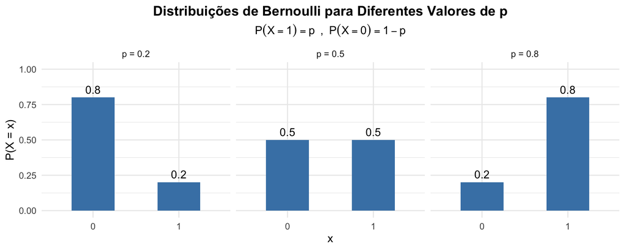

## Distribuição de Bernoulli

**Aplicações**

- **Modelos de Risco de Crédito**: VA: se uma empresa ou indivíduo dá default no pagamento de uma obrigação (1 = default, 0 = não).
- **Frequência de “sucessos” de estratégias de trading** VA: se o retorno de um ativo em um período é positivo (1) ou negativo (0).
- **Microestrutura de mercado:** VA: se em determinado minuto/hora ocorre ou não uma negociação de um ativo (1 = negociação, 0 = não).

## Distribuição Binomial

**Descrição**

#### **Princípios fundamentais** do processo que gera $Y_i$

Considere:

- $n$ ensaios *i.i.d* de Bernoulli: $y_1,\ldots,y_n$
- Os ensaios são **indepentendes**
- Os ensaios são **identicamente distribuídos**
- Observamos: $Y = \sum_{i=1}^{n} y_i$

#### Função (massa) de Probabilidade

- Se $Y$ é uma VA que representa este fenômeno, então, a função de probabilidade de $Y$ é dada por:

$$P(Y = y|p) = \binom{n}{y} p^k (1-p)^{n-k}$$

para $x = \{0,1,\ldots,n\}$ e 0 caso contrário.

Explicação:

- $\binom{n}{y}$ por que ambos, $(1 0 1)$ e $(1 1 0)$ produzem $y = 2$
- $\pi^y$ porque $y$ sucessos com probabilidade $\pi$ cada (produto tomada devido à independência)
- $(1 - \pi)^{n-y}$ porque $n-y$ fracassos em com probabilidade $(1 - \pi)$ cada.

#### Alguns Momentos

$E(Y) = np$

## Distribuição Binomial

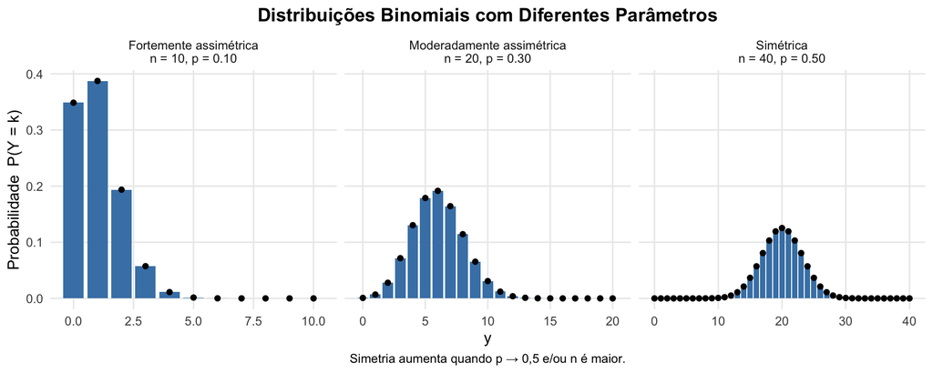

## Distribuição Binomial

**Aplicações**

- **Modelos de Risco de Crédito**: VA: número total de defaults em determinado período.
- **Frequência de “sucessos” de estratégias de trading** VA: quantidade de dias com retorno positivo no mês
- **Marketing:** Uma empresa envia $n$ e-mails promocionais, cada um com probabilidade $p$ de resultar em uma compra. VA: número de compras resultantes da campanha.

## Função `sample()` — Amostragem **com reposição**

**Ideia**

`sample()` com `replace = TRUE` gera tentativas **independentes**; ao contar sucessos (1s), obtemos uma variável **Binomial**.

**Sintaxe básica**

```r
sample(x, size, replace = TRUE, prob = NULL)
```

**Argumentos**

- `x`: espaço amostral (ex.: `c(0,1)` para fracasso/sucesso).
- `size`: nº de sorteios (tentativas).
- `replace = TRUE`: **com reposição** (tentativas i.i.d.).
- `prob`: probabilidades de cada elemento de `x` (R normaliza).

#### Exemplo 1 — “Moeda” com viés (Binomial)

```r
set.seed(123)
n <- 20  # nº de lançamentos
p <- 0.3 # probabilidade de sucesso
# 1 = sucesso, 0 = fracasso
lanc <- sample(c(0,1), size = n, replace = TRUE, prob = c(1-p, p))
sum(lanc)  # nº de sucessos ~ Binomial(n, p)
```

#### Exemplo 2 — Probabilidades desiguais em categorias

```r
# para reprodutibilidade
set.seed(123)
# 3 estados
estados <- c("Minas Gerais", "Espírito Santo", "Bahia")
# probabilidades de cada estado
p <- c(0.6, 0.3, 0.1)
# amostragem com reposição dos estados
amostra <- sample(cores, size = 10, replace = TRUE, prob = p)
amostra
```

**Boas práticas**

- Use `set.seed()` para reprodutibilidade.
- Para grandes simulações de contagens, prefira `rbinom()`; use `sample()` para **explicar o mecanismo**.

## Funções R para Distribuição Binomial

**Funções para a Distribuição Binomial**

| Função | Resultado |
| --- | --- |
| `rbinom(n, size, prob)` | Simula `n` valores (contagens de sucessos) |
| `dbinom(x, size, prob, log = FALSE)` | $P(X = x)$ no ponto `x` |
| `pbinom(q, size, prob, lower.tail = TRUE)` | $P(X \le q)$ (FDA) |
| `qbinom(p, size, prob, lower.tail = TRUE)` | Quantil: $F^{-1}(p)$ |

**Argumentos:**

- `size`: número de tentativas (n).
- `prob`: probabilidade de sucesso (p).
- `x`, `q`: inteiros $\in \{0,1,\ldots,\text{size}\}$.
- `lower.tail = FALSE` dá cauda superior (ex.: $P(X > q)$ como `pbinom(q, ..., lower.tail=FALSE)`).

## Distribuição Hipergeométrica

**Descrição**

#### **Princípios fundamentais** do processo que gera $Y_i$

- Podemos pensar a distribuição binomial como um bom modelo para o número de “sucessos” quando repetimos um ensaio (de Bernoulli) $n$ vezes, onde a probabilidade de sucesso é constante.
- Um experimento físico que implementa esta ideia é sortear bolas de uma urna na qual uma bola preta seja um sucesso e uma bola azul seja uma falha.
- De forma a garantir que $p$ seja constante de ensaio para ensaio, você precisa retornar a bola sorteada para a urna em cada ensaio, chamamos isso de *amostragem* **com reposição**.
- Mas e se você não retornar a bola para a urna? Nesse caso temos *amostragem* **sem reposição** e a VA $Y$ terá distribuição **hipergeométrica**.

#### Função (massa) de Probabilidade

- Seja $A$ o número de sucessos e $B$ o número de falhas e $n$ o número de amostras, então a VA $Y$ terá função (massa) de probabilidade dada por:

$$P(Y = y|p) = \frac{\binom{A}{y} \binom{B}{n - y}}{\binom{A + B}{n}}$$

Para $x$ inteiro e $\max\{0, n - B\} \leq y \leq \min\{n, A\}$ e 0, caso contrário.

- Se $N = A + B$ for muito mairo que $n$ $(N = A + B \gg n)$, a distribuição binomial é uma boa aproximação para a distribuição hipergeométrica.

#### Alguns Momentos

$E(Y) = \frac{nA}{A + B}$

$V(Y) = n \frac{A}{A + B} \frac{B}{A + B} \frac{A + B - n}{A + B - 1}$

## Distribuição Hipergeométrica

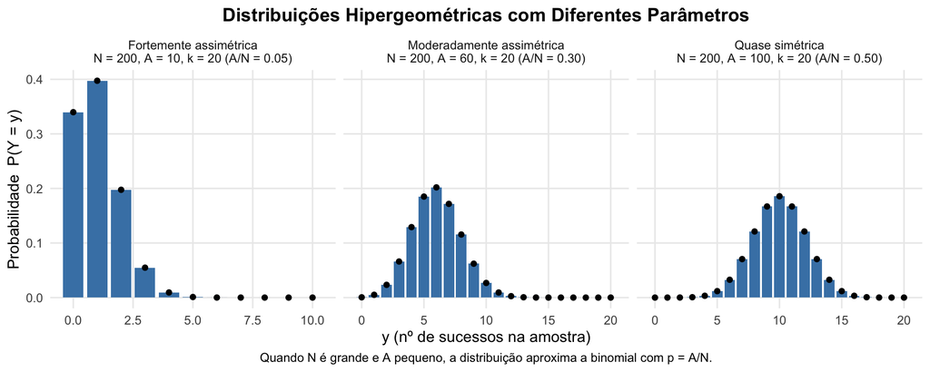

## Distribuição Hipergeométrica

**Aplicações**

- **Controle de Qualidade**: VA: uma fábrica produz um lote de $N$ itens, com $K$ defeituosos. Se o analista inspeciona $n$ itens sem reposição, o número de defeituosos segue uma hipergeométrica.
- **Auditoria Contábil:** VA: em um conjunto de $N$ lançamentos, $K$ apresentam não conformidade. Se o auditor amostra $n$ lançamentos sem reposição, o número de não conformidades segue uma hipergeométrica.

## Função `sample()` — Amostragem **sem reposição**

**Ideia**

`sample()` com `replace = FALSE` realiza sorteios **sem reposição** de uma população finita. Ao contar “sucessos”, obtemos uma **Hipergeométrica**.

**Sintaxe básica**

```r
sample(x, size, replace = FALSE)
```

**Argumentos**

- `x`: população finita (ex.: vetor de 1s e 0s).
- `size`: tamanho da amostra.
- `replace = FALSE`: **sem reposição** (dependência entre sorteios).

#### Exemplo — Controle de qualidade (Hipergeométrica)

```r
# para reprodutibilidade
set.seed(123)
N <- 100 # nº de itens na população
K <- 15  # nº de itens defeituosos
n <- 10  # tamanho da amostra

# Y: 1 = defeituoso, 0 = ok
# simula a população com defeituosos
pop <- c(rep(1, K), rep(0, N-K))
# realiza a amostragem
amostra <- sample(pop, size = n, replace = FALSE)
# nº de defeituosos na amostra ~ Hipergeométrica(N, K, n)
sum(amostra)
```

**Boas práticas**

- Em amostragem sem reposição com grandes N, `phyper`/`rhyper` são mais eficientes; use `sample()` para **ilustrar o procedimento**.

## Funções R para Distribuição Hipergeométrica

**Funções para a Distribuição Hipergeométrica**

| Função | Resultado |
| --- | --- |
| `rhyper(nn, m, n, k)` | Simula `nn` valores |
| `dhyper(x, m, n, k, log = FALSE)` | $P(X = x)$ no ponto `x` |
| `phyper(q, m, n, k, lower.tail = TRUE)` | $P(X \le q)$ (FDA) |
| `qhyper(p, m, n, k, lower.tail = TRUE)` | Quantil: $F^{-1}(p)$ |

**Argumentos:**

- `m`: nº de itens “sucesso” na população (ex.: brancos).
- `n`: nº de itens “fracasso” na população (ex.: pretos).
- `k`: tamanho da amostra **sem reposição**.
- População total $N = m + n$; suporte $x \in \{\max(0, k-n), \ldots, \min(k, m)\}$.
- `lower.tail = FALSE` retorna a cauda superior (ex.: $P(X > q)$ como `phyper(q, ..., lower.tail = FALSE)`).

## Distribuição de Poisson

**Descrição**

#### **Princípios fundamentais** do processo que gera $Y_i$

A distribuição de Poisson expressa a probabilidade de um dado número de eventos ocorrerem em um intervalo de tempo fixo se:

- o evento pode ser contado em números inteiros;
- as ocorrências forem independentes, e;
- a frequência média de ocorrência para um período de tempo for conhecida.

A melhor forma de descrever a distribuição de Poisson é por meio de um conjunto de exigências denominadas “*Postulados de Poisson*”. Se uma VA satisfaz estas exigências, dizemos que ela possui distribuição de Poisson:

Formalmente, para $t \geq 0$, sejam $N_t$ VAs com valores inteiros, se $N_t$ satisfaz:

1. $N_0 = 0$
2. para $s < t$, $N_s$ e $N_t - N_s$ são independentes (ocorrências são independentes em intervalos disjuntos)
3. $N_s$ e $N_{t + s} - N_t$ tem distribuições idênticas (o número de ocorrências depende apenas da duração do período)
4. $\lim_{t \to 0} \frac{P(N_t = 1)}{t} = \gamma$ ($\gamma$ é a taxa de ocorrências, a qual é constante para pequenos intervalos)
5. $\lim_{t \to 0} \frac{P(N_t > 1)}{t} = 0$ (não há ocorrências simultâneas)
- Então, para qualquer inteiro não-negativo $k$:

$$P(N_t = k) = \frac{(\gamma t)^k e^{- t\gamma}}{k!}$$

$\gamma$ e $t$ sempre aparecem juntos, então combinamos eles em um parâmetro $\lambda = \gamma t$. $\gamma$ é a propensão de ocorrências por unidade de tempo. $t$ é o número de unidades de tempo $\lambda$ é a propensão de ocorrências em um determinado período de tempo.

#### Função (massa) de Probabilidade

- Se $Y$ é uma VA que satistaz as condições de 1 a 5, então, a função de probabilidade de $Y$ é dada por:

$$P(Y = y|\lambda) = \frac{\lambda^k e^{-\lambda}}{k!}$$

com $\lambda > 0$ e para $x = \{0,1,2,\ldots\}$, 0 caso contrário.

#### Alguns Momentos

$E(Y) = \lambda$

$V(Y) = \lambda$

## Distribuição de Poisson

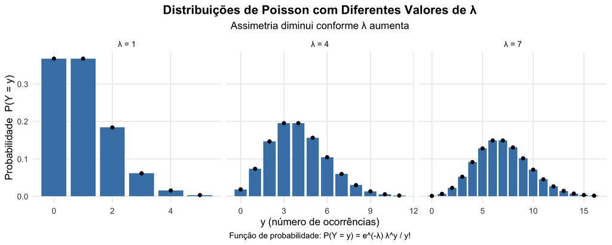

## Distribuição de Poisson

**Aplicações**

- **VA: Número de negociações em um intervalo de tempo:**. em mercados financeiros de alta frequência, o número de transações em janelas fixas (1 min, 5 min) pode ser modelado por Poisson
- **VA: Número de defaults em pequenas carteiras de crédito:** Quando a probabilidade de default é pequena mas existem muitos contratos, o número de defaults em certo período pode ser aproximado por Poisson.
- **VA: Número de reclamações de clientes em um período de tempo:**, modela o número de reclamações chegam ao SAC por semana.
- **VA: Frequência de acidentes de trabalho em uma fábrica**

## Funções R para Distribuição de Poisson

**Funções para a Distribuição de Poisson**

| Função | Resultado |
| --- | --- |
| `rpois(n, lambda)` | Simula `n` valores (contagens) |
| `dpois(x, lambda, log = FALSE)` | $P(X = x)$ no ponto `x` |
| `ppois(q, lambda, lower.tail = TRUE)` | $P(X \le q)$ (FDA) |
| `qpois(p, lambda, lower.tail = TRUE)` | Quantil: $F^{-1}(p)$ |

**Argumentos:**

- `lambda > 0`: taxa média ($\lambda$).
- `x`, `q`: inteiros não negativos ($x, q \in \{0,1,2,\ldots\}$).
- `lower.tail = FALSE` retorna a cauda superior (ex.: $P(X > q)$ via `ppois(q, ..., lower.tail = FALSE)`, equivalente a $P(X \ge q+1)$ na discreta).

## Distribuição Binomial Negativa

**Descrição**

#### **Princípios fundamentais** do processo que gera $Y_i$

- Considere uma sequência de ensaios *i.i.d* de Bernoulli: $y_1,\ldots,y_n$, e seja $Y$ o número total de ensaios necessários para obter $r$ sucessos.
- Nesse caso, $Y$ é uma VA com distribuição binomial negativa.
- Em alguns livros, vemos esta distribuição definida de forma alternativa, mas equivalente: $Y$ é o número de *falhas*, não ensaios, necessário para obter $r$ sucessos.

#### Função (massa) de Probabilidade

- Se $Y$ é uma VA que representa este fenômeno, então, a função de probabilidade de $Y$ é dada por:

$$P(Y = y|p,r) = \binom{y - 1}{r - 1} p^r (1 - p)^{y - r}$$

- Para $\{x = r, r + 1, \ldots\}$ e 0 caso contrário.

Explicação:

- $\binom{y - 1}{r - 1}$ é o número de sequências com $r - 1$ sucessos e$y - r$ falhas.
- $p$ é a probabilidade de sucesso após $r - 1$ falhas
- $p^r (1 - p)^{y - r}$ é é a probabilidade de qualquer sequência com $r - 1$ sucessos e $y - r$ falhas.

#### Valor Esperado e Variância

$E(Y) = \frac{r(1 - p)}{p}$

$V(Y) = \frac{r(1 - p)}{p^2}$

#### Distribuição Geométrica

- Uma distribuição binomial negativa com $r = 1$ é denominada uma distribuição geométrica.
- Ou seja, estamos interessados no número de falhas até o primeiro sucesso.
- A função de probabilidade é dada por:
  $$P(Y = y|p) = p(1 - p)^{y}$$

para $x = \{0,1,2,\ldots\}$ e 0 caso contrário.

## Distribuição Binomial Negativa

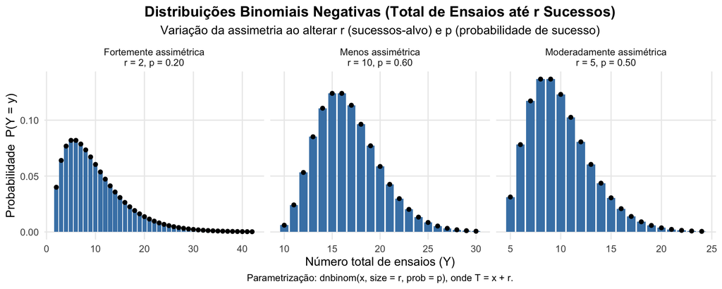

## Distribuição Binomial Negativa

**Aplicações**

## Funções R para Distribuição Binomial Negativa

**Funções para a Distribuição Binomial Negativa**

| Função | Resultado |
| --- | --- |
| `rnbinom(n, size, prob, mu)` | Simula `n` valores (falhas até o $r$-ésimo sucesso) |
| `dnbinom(x, size, prob, mu, log = FALSE)` | $P(X = x)$ no ponto `x` |
| `pnbinom(q, size, prob, mu, lower.tail = TRUE)` | $P(X \le q)$ (FDA) |
| `qnbinom(p, size, prob, mu, lower.tail = TRUE)` | Quantil: $F^{-1}(p)$ |

**Argumentos:**

- `size = r > 0`: número de sucessos alvo ($r$).
- Use **ou** `prob \in (0,1]` **ou** `mu > 0` (não ambos).
- Relação entre parametrizações: $\mu = r\frac{1-p}{p}$ e $p = \frac{r}{r+\mu}$.
- Suporte: $x \in \{0,1,2,\ldots\}$ (nº de **falhas** antes do $r$-ésimo sucesso).
- `lower.tail = FALSE` retorna a cauda superior ($P(X > q)$, equivalente a $P(X \ge q+1)$ na discreta).

# Distribuicões de Variáveis Aleatórias Contínuas

## Distribuição Uniforme Contínua

**Descrição**

#### **Princípios fundamentais** do processo que gera $Y_i$

Para distribuições uniformes contínuas, a probabilidade de $Y$ estar em um certo sub-intervalo $[a,b]$ depende somente do comprimento do intervalo.

#### Função (densidade) de Probabilidade

- Se $Y$ é uma VA que satisfaz à condição anterior, então, a função (densidade) probabilidade de $Y$ é dada por:

$$f_Y(y)=
\begin{cases}
\frac{1}{b - a} & \text{se } a \leq y \leq b \\
0 & \text{caso contrário}
\end{cases}$$

#### Alguns Momentos

$E(Y) = \frac{a + b}{2}$

$V(Y) = \frac{(b - a)^2}{12}$

## Distribuição Uniforme Contínua

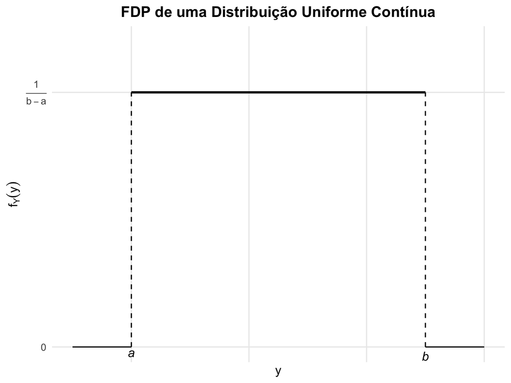

## Distribuição Uniforme Contínua

**Aplicações**

- **Métodos de Simulação de Monte Carlo:** a distribuição uniforme contínua é a base de todos os métodos de simulação.
- **Preços em leilões simulados:** Em experimentos de leilões, é comum assumir que os lances iniciais dos participantes são extraídos de uma uniforme.
- **Pesquisas de Marketing:** ao simular escolhas quando não há informação prévia, pode-se assumir que a propensão inicial dos consumidores a escolher entre duas marcas segue uma distribuição uniforme.
- **Inferência Bayesiana**: Distribuição a priori não informativa. Métodos de Simulação de Monte Carlo via Cadeias de Markov

## Funções R para Distribuição Uniforme Contínua

**Funções para a Distribuição Uniforme Contínua**

| Função | Resultado |
| --- | --- |
| `runif(n, min = 0, max = 1)` | Simula `n` valores |
| `dunif(x, min = 0, max = 1, log = FALSE)` | Densidade: $f(x)$ no ponto `x` |
| `punif(q, min = 0, max = 1, lower.tail = TRUE)` | $P(X \le q)$ (CDF) |
| `qunif(p, min = 0, max = 1, lower.tail = TRUE)` | Quantil: $F^{-1}(p)$ |

**Argumentos:**

- Intervalo: `min = a`, `max = b` com $a < b$.
- Suporte: $x \in [a,b]$.
- `lower.tail = FALSE` retorna cauda superior (ex.: $P(X > q)$ via `punif(q, ..., lower.tail = FALSE)`).

## Distribuição Beta

**Descrição**

#### **Princípios fundamentais** do processo que gera $Y_i$

- A distribuição beta é usada como uma família paramétrica flexível entre $[0,1]$.

#### Função (densidade) de Probabilidade

- Uma variável aleatória $Y$ que segue uma distribuição Beta, possui função densidade de probabilidade dada por:

$$f_Y(Y|\alpha,\beta) = \frac{1}{B(\alpha,\beta)} y^{\alpha - 1} (1 - y)^{\beta - 1} \, (0 \leq y \leq 1)$$

- Com $alpha > 0$ e $beta > 0$.
- Sendo $B(\alpha,\beta)$ a função beta dada por:

$$B(\alpha,\beta) = \int_0^1 t^{\alpha - 1} (1 - t)^{\beta - 1} = \frac{\Gamma(\alpha)\Gamma(\beta)}{\Gamma(\alpha + \beta)}$$

- E $\Gamma(x)$ a função gama dada por:

$$\Gamma(x) = \int_0^\infty t^{x - 1} e^{-t} \, dt \, (x > 0)$$

#### Alguns Momentos

$E(Y) = \frac{\alpha}{\alpha + \beta}$

$V(Y) = \frac{\alpha\beta}{(\alpha + \beta)^2(\alpha + \beta + 1)}$

## Distribuição Beta

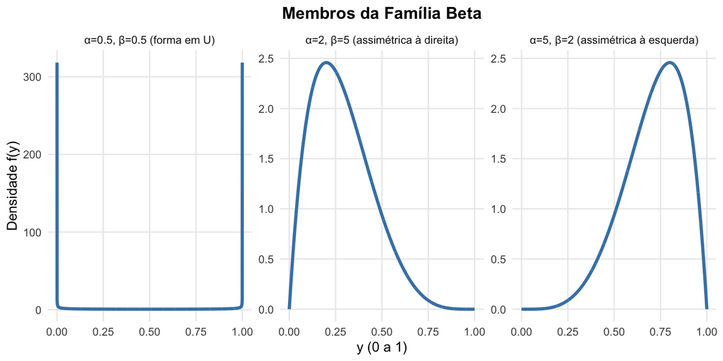

## Distribuição Beta

**Aplicações**

- **Modelagem de proporções em regressões:** Quando a variável dependente é uma proporção/taxa (ex.: participação de mercado, taxa de conversão em marketing, taxa de ocupação hoteleira, proporção de mulheres em conselhos de administração…), pode-se usar regressão Beta.
- Há várias outras.

## Funções R para Distribuição Beta

**Funções para a Distribuição Beta**

| Função | Resultado |
| --- | --- |
| `rbeta(n, shape1, shape2)` | Simula `n` valores |
| `dbeta(x, shape1, shape2, log = FALSE)` | Densidade: $f(x)$ no ponto `x` |
| `pbeta(q, shape1, shape2, lower.tail = TRUE)` | $P(X \le q)$ (CDF) |
| `qbeta(p, shape1, shape2, lower.tail = TRUE)` | Quantil: $F^{-1}(p)$ |

**Argumentos:**

- `shape1` = $\alpha > 0$, `shape2` = $\beta > 0$.
- `lower.tail = FALSE` retorna cauda superior (ex.: $P(X > q)$ via `pbeta(q, ..., lower.tail = FALSE)`).

## Distribuição Normal (Gaussiana)

**Descrição**

#### **Princípios fundamentais** do processo que gera $Y_i$

- A distribuição normal é a distribuição de probabilidade mais importante em econometria aplicada.
- Muitos procedimentos de inferência usam distribuições derivadas da normal para valores críticos.
- O modelo de regressão linear é construído em torno da distribuição normal.
- Muitos estimadores e estatísticas de testes possuem a distribuição normal como distribuição assintótica.
- Consequentemente, é importante entender as propriedades da distribuição normal e aquelas que dela derivam.

#### Função Densidade

Uma variável aleatória (VA) $Y$ com distribuição normal, representada por $Y \sim N(\mu, \sigma^2)$, possui fdp dada por:

$$f(y) = \frac{1}{\sigma \sqrt{2\pi}} e^{-\frac{(y-\mu)^2}{2\sigma^2}}$$

Com $y \in \mathbb{R}$, $\mu \in \mathbb{R}$ e $\sigma > 0$.

#### Distribuição Normal Padrão

Quando padronizamos $Y$ com $Z = \frac{Y - \mu}{\sigma}$, temos $\mu = 0$ e $\sigma = 1$, o que origina a distribuição normal padronizada e sua fdp é usualmente representada por $\phi(y)$ e sua função de distribuição por $\Phi(y)$.

#### Função de Distribuição Acumulada

A função de distribuição acumulada padronizada não está disponível em forma fechada, mas é escrita como:

$$\Phi(y) = \int_{-\infty}^y \phi(u) du$$

#### Alguns Momentos

- $E[X] = \mu$ (parâmetro de locação)
- $V[X] = \sigma^2$ $\rightarrow$ $\sigma = \sqrt{\sigma^2}$ (parâmetro de escala)

## Distribuição Normal Padronizada

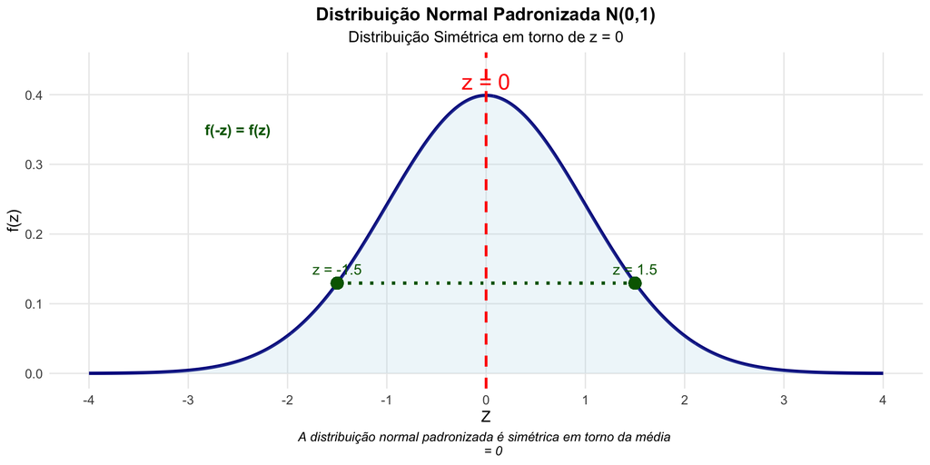

## Efeitos de $\mu$ e $\sigma$

- Alterando $E[X]=\mu$
- Alterando $\sigma^2$

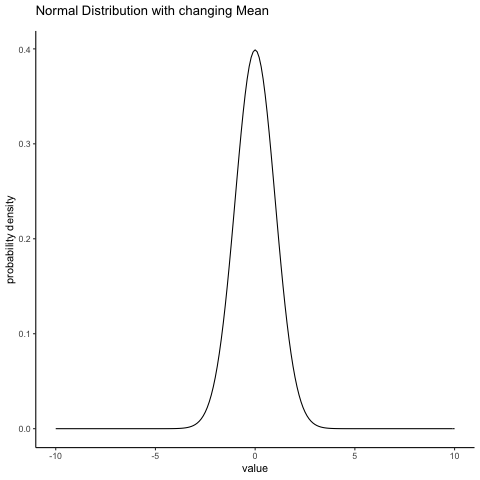

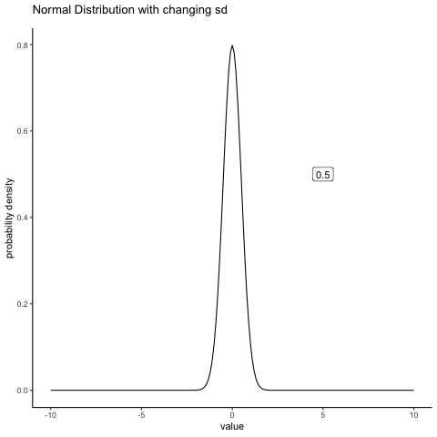

## Distribuicão da Soma de VAs com Distribuição Normal

**Propriedades**

Há muitas coisas epsecias sobre a distribuição normal, e uma das propriedades mais úteis é a seguinte:

#### Teorema

Se $X_1, X_2,\ldots, X_n$ são variáveis aleatórias i.i.d com $X_i \sim N(\mu_i, \sigma_i^2)$. Então a distribuição da soma de $Y = X_1, X_2,\ldots, X_n = \sum_{i = 1}^n X_i$ também possui distribuição normal:

$$Y = \sum_{i = 1}^n X_i \sim N(\sum_{i = 1}^n \mu_i, \sum_{i = 1}^n \sigma_i^2)$$

## Distribuição Normal

**Aplicações**

- **Importância Teórica:** é a base dos métodos de inferência estatística. É a base dos modelos de regressão linear e de vários outros métodos estatísticos e econométricos.
- **Finanças:** Valor-em-Risco (VaR) conisderando que a distribuição dos retornos sigam uma distribuição normal.
- **Auditoria:** Modelagem de erros contábeis e fraudes. A distribuiçõa normal é usada como benchmark em auditorias. Desvios sistemáticos da normal sugerem manipulações ou fraudes.
- **Simulação de Monte Carlo:** Muito usada para simular diversas variáveis aleatórias.

## Funções R para Distribuição Normal

**Funções para a Distribuição Normal**

| Função | Resultado |
| --- | --- |
| `rnorm(n, mean = 0, sd = 1)` | Simula `n` valores |
| `dnorm(x, mean = 0, sd = 1)` | Densidade $f(x)$ |
| `pnorm(q, mean = 0, sd = 1, lower.tail = TRUE)` | $P(X \le q)$ (CDF) |
| `qnorm(p, mean = 0, sd = 1, lower.tail = TRUE)` | Quantil: $\Phi^{-1}(p)$ |

**Argumentos Principais**

- `q`: ponto(s) onde avaliar $P(X \le q)$.
- `p \in (0,1)`: probabilidade para obter o quantil (em `qnorm`).
- `lower.tail`: `TRUE` calcula cauda inferior $P(X \le q)$; `FALSE` calcula cauda superior $P(X > q)$.
- Argumentos são vetorizados: `x`, `q` e `p` podem ser vetores.

## Distribuição Log-Normal

**Descrição**

#### **Princípios fundamentais** do processo que gera $Y_i$

- Um uso comum da distribuição log-normal em Economia é para modelar salários, rendas e preços de imóveis. Essas VAs são positivas e as distribuições são assimétricas com uma cauda longa para a direita, indicando que uma pequena parcela da população apresenta valores altos.

#### Função (densidade) de Probabilidade

- Diz-se que uma VA $Y$ possui distribuição log-normal se $\log(Y )\sim N(\mu, \sigma^2)$ para $y > 0$. Nesse caso, a fdp de $Y$ é dada por:

$$f_Y(y|\mu,\sigma) = \frac{1}{y\sigma\sqrt{2\pi}} \exp \Bigl \{ - \frac{[\ln(y) - \mu]^2}{2\sigma^2} \Bigr \}$$

#### Alguns Momentos

$E(Y) = \exp\{ \mu + \frac{1}{2\sigma^2} \}$

$V(Y) = \exp(2\mu + \sigma^2) (\exp(\sigma^2 - 1))$

## Distribuição Log-Normal

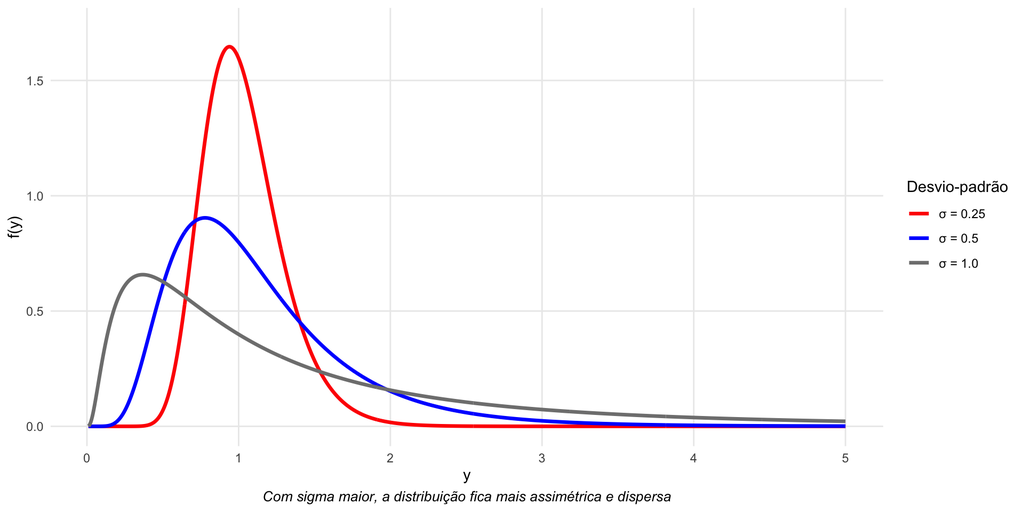

## Distribuição Log-Normal

**Aplicações**

- **Modelagem de preços de ativos financeiros**: Assumida no modelo de **Black-Scholes** para precificação de opções. Garante que os preços dos ativos sejam sempre positivos.
- **Distribuição de renda e riqueza:** a renda pessoal e a riqueza são frequentemente modeladas como log-normais, pois são **positivas**. Têm assimetria positiva (muitos pobres, poucos ricos).
- **Custos e tempos em projetos e operações:** Aplicada em custos de produção, tempos de execução e prazos de entrega, que tendem a crescer multiplicativamente e não negativamente.
- **Avaliação de empresas (valuation):** Modelagem do crescimento de fluxos de caixa ou lucros em modelos probabilísticos de avaliação de empresas.

## Funções R para Distribuição Log-normal

**Funções para a Distribuição Log-normal**

| Função | Resultado |
| --- | --- |
| `rlnorm(n, meanlog = 0, sdlog = 1)` | Simula `n` valores |
| `dlnorm(x, meanlog = 0, sdlog = 1, log = FALSE)` | Densidade $f(x)$ |
| `plnorm(q, meanlog = 0, sdlog = 1, lower.tail = TRUE)` | $P(X \le q)$ (CDF) |
| `qlnorm(p, meanlog = 0, sdlog = 1, lower.tail = TRUE)` | Quantil: $F^{-1}(p)$ |

# Distribuições de Probabilidade de Vetores Aleatórios

## Vetor Aleatório

**Definições**

Considere um vetor aleatório $\mathbf{X} \in \mathbb{R}^m$

#### Vetor Aleatório Multivariado

Um **vetor aleatório multivariado** é uma função com domínio no espaço amostral para $\mathbb{R}^m$, que pode ser escrito como:

$$\mathbf{X} = (X_1, X_2, \ldots, X_n)^\top$$

Agora definiremos as FDP e FDA para vetores aleatórios multivariados.

#### Função de Distribuição Conjunta

A **função de distribuição conjunta** de $\mathbf{X}$ é:

$$F_X(x) = P(X \leq x) = P(X \leq x_1 \cap X \leq x_2 \cap \ldots \cap X \leq X_n)$$

#### Valor Esperado

O valor esperado de $\mathbf{X} \in \mathbb{R}^m$ é o vetor dos valores esperados de seus elementos:

$$E[\mathbf{X}] =
\begin{bmatrix}
E[X_1] \\
E[X_2] \\
\vdots \\
E[X_m]
\end{bmatrix}$$

#### Matriz de Covariâncias

A matriz $(m \times m)$ de covariâncias (ou de variância-covariância) de $\mathbf{X} \in \mathbb{R}^m$ é:

$$V(\mathbf{X}) = \Sigma = E[(X - E(X))(X - E(X))^\top]$$

Quando aplicada a um vetor aleatório $V(\mathbf{X})$ é uma matriz:

$$\begin{align*}
V(\mathbf{X})
&= E\big[(\mathbf{X} - E[\mathbf{X}])(\mathbf{X} - E[\mathbf{X}])^\top\big] \\[6pt]
&= \begin{bmatrix}
V(X_1) & \operatorname{Cov}(X_1,X_2) & \cdots & \operatorname{Cov}(X_1,X_m) \\
\operatorname{Cov}(X_2,X_1) & V(X_2) & \cdots & \operatorname{Cov}(X_2,X_m) \\
\vdots & \vdots & \ddots & \vdots \\
\operatorname{Cov}(X_m,X_1) & \operatorname{Cov}(X_m,X_2) & \cdots & V(X_m)
\end{bmatrix} \\[6pt]
&= \begin{bmatrix}
\sigma_1^2 & \sigma_{12} & \cdots & \sigma_{1m} \\
\sigma_{21} & \sigma_2^2 & \cdots & \sigma_{2m} \\
\vdots & \vdots & \ddots & \vdots \\
\sigma_{m1} & \sigma_{m2} & \cdots & \sigma_m^2
\end{bmatrix}
\end{align*}$$

sendo $\sigma_{j}^2 = V(X_j)$ e $\sigma_{ij} = Cov(X_i,X_j)$ para $i,j = 1, 2, \ldots, m$ e $i \neq j$.

#### Teorema 1: Propriedade da Matriz de Covariâncias

Qualquer matriz de covariâncias $\Sigma$ $(m \times m\)$ satisfaz:

1. $\Sigma$ é **simétrica**: $\Sigma = \Sigma^\top$
2. $\Sigma$ é semi-definida positiva

#### Teorema 2: Propriedade da Matriz de Covariâncias

Se $\mathbf{X} \in \mathbb{R}^m$ com $E(\mathbf{X})_{m \times 1} = \mu$ e matriz de covariâncias $\Sigma_{m \times m}$ e $\mathbf{A}_{q \times m}$, então $\mathbf{A}\mathbf{X}$ é um vetor aleatório com valor esperado $\mathbf{A}\mu$ e matriz de covariências $\mathbf{A} \Sigma \mathbf{A}^{T}$.

## Distribuição Bivariada

**Definições**

- A maioria dos conceitos para pares de variáveis aleatórias se aplica a vetores multivariados.
- Seja $(X,Y)$ um par de VAs de dimensão $m_X$ e $m_Y$, respectivamente. Para facilitar a apresentação, focamos no caso de vetores aleatórios contínuos.

#### Funcão de Distribuição Conjunta

A função de **distribuição conjunta** de $(X,Y) \in \mathbb{R}^{m_X} \times \mathbb{R}^{m_Y}$ é:

$$F(x,y) = P(X \leq x \cap Y \leq y)$$

#### Função Densidade Conjunta

A função de **densidade conjunta** de $(X,Y) \in \mathbb{R}^{m_X} \times \mathbb{R}^{m_Y}$ é:

$$f(x,y) = \frac{\partial^{m_X + m_Y}}{\partial X \partial Y} F(x,y)$$

#### Funções de Densidades Marginais

As funções de **densidade marginais** de $X$ e $Y$ são:

$$f_X(x) = \int f(x,y) dy$$

$$f_Y(y) = \int f(x,y) dx$$

#### Funções de Densidades Condicionais

As **densidades condicionais** de $Y$ dado $X = x$ e de $X$ dado $Y = y$ são:

$$f_{Y|X}(y|x) = \frac{f(x,y)}{f_X(x)}$$

$$f_{X|Y}(x|y) = \frac{f(x,y)}{f_Y(y)}$$

#### Valor Esperado Condicional

O **valor esperado condicional** de $Y$ dado $X = x$ é:

$$E(Y | X = x) = \int f_{Y|X}(y|x)dy$$

#### Independência

Os vetores aleatórios $X$ e $Y$ são **independentes** se sua densidade conjunta pode ser fatorada como:

$$f(x,y) = f_X(x) \cdot f_Y(y)$$

As variáveis aleatórias contínuas $(X_1,\ldots,X_m)$ são **mutuamente independentes** se sua densidade conjunta pode ser fatorada no produto das densidades marginais:

$$f(x_1,\ldots,x_m) = f_1(x_1) \ldots f_m(x_m)$$

## Distribuição Normal Multivariada

**Descrição**

#### **Princípios fundamentais** do processo que gera $Y_i$

A pergunta que se pode fazer é: “Por que a distribuição normal multivariada é tão importante?” Existem três razões principais:

1. **Simplicidade Matemática:** É uma distribuição é relativamente fácil de trabalhar, por isso é fácil obter métodos multivariados com base nessa distribuição específica.
2. **Versão multivariada do Teorema Central do Limite:** ÉVocê pode se lembrar que há um teorema central do limite para a média da amostra para grandes amostras de variáveis aleatórias. Um resultado semelhante está disponível em estatísticas multivariadas que dizem que se tivermos uma coleção de vetores aleatórios que são independentes e distribuídos de forma idêntica, então o vetor médio da amostra, terá distribuicão aproximadamente normal multivariada normal para amostras grandes.
3. Diversos fenômenos naturais também podem ser modelados usando essa distribuição, assim como no caso univariado.

#### Função de Densidade Conjunta

- Se tivermos um vetor aleatório $p x 1$ que é distribuído de acordo com uma distribuição normal multivariada com um vetor médio populacional $(E(\mathbf{X}) = \mu)$ e uma matriz de covariância populacional ($\Sigma$), então esse vetor aleatório terá a seguinte função de densidade conjunta:

$$f(\textbf{x})=\left(\frac{1}{2\pi}\right)^{p/2}|\Sigma|^{-1/2}\exp\{-\frac{1}{2}(\textbf{x}-\mathbf{\mu})'\Sigma^{-1}(\textbf{x}-\mathbf{\mu})\}$$

- $|\Sigma|$ denota o determinante da matriz de variância-covariância $\Sigma$ e $\Sigma^{-1}$ é a inversa da matriz de covariâncias. Se $p = 2$ temos uma **distribuição normal bivariada**.
- A notação abreviada, semelhante à versão univariada acima, é $\mathbf{X} \sim N(\mathbf{\mu},\Sigma)$, que lemos como: O vetor aleatório $\mathbf{X}$ é distribuído como normal multivariadA com vetor médio $\mu$ e matriz de covariância $\Sigma$.

#### Características importantes da Distribuição Normal Multivariada:

1. O seguinte termo que aparece dentro do expoente da distribuição normal multivariada é uma **forma quadrática**:

$$(\textbf{x}-\mathbf{\mu})'\Sigma^{-1}(\textbf{x}-\mathbf{\mu})$$

Essa forma quadrática específica também é chamada de **distância de Mahalanobis** entre o vetor aleatório $\mathbf{X}$ e o vetor médio $\mu$.

2. Sejam $\{Z_1, Z_2,\ldots, Z_m\}$ i.i.d $N(0, 1)$. Como as $Z_i$ são mutuamente independentes, a densidade conjunta é o produto das densidades marginais, assim:

$$\begin{align*}
f(x_1,\dots,x_m) &= f(x_1)f(x_2)\dots f(x_m), \\
&= \prod_{i=1}^m \frac{1}{\sqrt{2\pi}}\exp \bigl \{-\frac{1}{2}x_i^2 \bigr \} \\
&= \frac{1}{(2\pi)^{m/2}} \exp \bigl \{-\frac{1}{2}\sum_{i=1}^m x_i^2 \bigr \} \\
\phi(\textbf{x}) &= \frac{1}{(2\pi)^{m/2}} \exp \bigl \{-\frac{1}{2}\mathbf{x}'\mathbf{x} \bigr \}
\end{align*}$$

Que é a função de densidade normal padronizada multivariada, $\mathbf{Z} \sim N(0,\mathbf{I}_m)$, com $E(\mathbf{Z}) = 0$ e $V(\mathbf{Z}) = \mathbf{I}_m$.

3. Se as VAs $(X_1, X_2,\ldots,X_n)$ forem i.i.d, a matriz de covariâncias será uma matriz diagonal com as variâncias das variáveis individuais na diagonal principal da matriz e zeros para as covariâncias:

$$\Sigma = \left(\begin{array}{cccc}\sigma^2_1 & 0 & \dots & 0\\ 0 & \sigma^2_2 & \dots & 0\\ \vdots & \vdots & \ddots & \vdots\\ 0 & 0 & \dots & \sigma^2_p \end{array}\right)$$

## Simulação da Normal Multivariada

**`MASS::mvrnorm()`**

| Função | Resultado |
| --- | --- |
| `MASS::mvrnorm(n, mu, Sigma, ...)` | Simula `n` vetores em $\mathbb R^k$ com média $\boldsymbol\mu$ e covariância $\boldsymbol\Sigma$ |

**Argumentos principais**

- `n`: número de observações (linhas) a gerar.
- `mu`: vetor de médias $\boldsymbol\mu \in \mathbb R^k$ (dimensão $k$).
- `Sigma`: matriz de covariância $\boldsymbol\Sigma \in \mathbb R^{k \times k}$ (**simétrica** e (semi) **definida positiva**).
- `empirical = FALSE/TRUE`: se `TRUE`, força a **média amostral** e a **covariância amostral** a serem exatamente `mu` e `Sigma` (útil para fins didáticos).

**Observações**

- Retorno: matriz `n × k` (se `n = 1`, retorna um **vetor**).

**Outras funções (FDA/densidade/quantis)**

- Para densidade/CDF/quantis multivariados, use o pacote `mvtnorm`: `dmvnorm()`, `pmvnorm()`, `qmvnorm()`.

## Simulação: Dist. Normal Bivariada

```r
# ------------------------------------------------------------
# Reprodutibilidade: fixa a semente do gerador de números aleatórios
# ------------------------------------------------------------
set.seed(123)

# ------------------------------------------------------------
# Dimensão do vetor aleatório: k = 2  (variáveis X1 e X2)
# Vetor de médias: mu = (mu1, mu2)
#   - mu1 = E[X1]
#   - mu2 = E[X2]
# ------------------------------------------------------------
mu <- c(0, 1)   # E[X1] = 0, E[X2] = 1

# ------------------------------------------------------------
# Matriz de covariância 2x2: Sigma
#  - Diagonal: variâncias Var(X1) e Var(X2)
#  - Fora da diagonal: covariâncias Cov(X1, X2) = Cov(X2, X1)
#  - Deve ser SIMÉTRICA e (semi) DEFINIDA POSITIVA
#
# byrow = TRUE: os elementos são preenchidos por LINHA
#   [ [ 1.0, 0.6 ],
#     [ 0.6, 2.0 ] ]
#  -> Var(X1)=1, Var(X2)=2, Cov(X1,X2)=0.6
# ------------------------------------------------------------
Sigma <- matrix(c(1, 0.6,
                  0.6, 2), nrow = 2, byrow = TRUE)

# ------------------------------------------------------------
# Simulação da normal multivariada:
#   X ~ N_k(mu, Sigma) com k = 2
#   n = 5000 observações (linhas)
# Retorno:
#   - matriz 5000 x 2 (cada coluna é uma variável; cada linha, uma realização)
# ------------------------------------------------------------
X <- MASS::mvrnorm(n = 5000, mu = mu, Sigma = Sigma)

# ------------------------------------------------------------
# Momentos amostrais:
#  - colMeans(X): estima E[X] = mu  (tende a (0, 1))
#  - cov(X):      estima Var(X) = Sigma
# ------------------------------------------------------------
colMeans(X)
```

```
[1] 0.0028401 0.9977198
```

```r
cov(X)
```

```
        [,1]    [,2]
[1,] 1.00471 0.59386
[2,] 0.59386 1.97460
```

```r
# ------------------------------------------------------------
# Correlação amostral entre X1 e X2:
#  cor(X)[1, 2] ~ rho = Cov(X1,X2) / (sd(X1)*sd(X2))
#  Teoricamente, rho = 0.6 / sqrt(1*2) ≈ 0.4243
# ------------------------------------------------------------
cor(X)[1, 2]
```

```
[1] 0.42163
```

## Distribuição Normal Bivariada

**Descrição**

- Para entender melhor a distribuição normal multivariada, é útil olhar para a distribuição normal bivariada.
- Nesse caso, temos apenas duas VAs, $Y$ e $X$, e estas são normalmente distribuídas vetor de médias $\mu_X$ e $\mu_Y$ e matriz de covariância mostrada abaixo:

$$\left(\begin{array}{c}Y\\X \end{array}\right) \sim N \left[\left(\begin{array}{c}\mu_Y\\ \mu_X \end{array}\right), \left(\begin{array}{cc}\sigma^2_Y & \rho \sigma_Y\sigma_X \\ \rho\sigma_Y\sigma_X & \sigma^2_X \end{array}\right)\right]$$

- O determinante da matriz de covariância é dado por:

$$|\Sigma| = \sigma^2_Y\sigma^2_X(1-\rho^2)$$

- E a inversa da matriz de covariância é:

$$\Sigma^{-1} = \dfrac{1}{\sigma^2_Y\sigma^2_X(1-\rho^2)} \left(\begin{array}{cc}\sigma^2_X & -\rho \sigma_Y\sigma_X \\ -\rho\sigma_Y\sigma_X & \sigma^2_Y \end{array}\right)$$

#### Função de Densidade Conjunta

- Substituindo as expressões para o determinante e a inversa da matriz de covariância, obtemos, após alguma simplificação, a **função de densidade conjunta** do vetor aleatório $(Y,X)$ é a de uma distribuição normal bivariada:

$$\phi_{Y,X}(y,x) =
\dfrac{1}{2\pi\sigma_Y\sigma_X\sqrt{1-\rho^2}}
\exp\left\{
-\dfrac{1}{2(1-\rho^2)}
\left[
\left(\dfrac{y-\mu_Y}{\sigma_Y}\right)^2
\right.
\right.$$

$$\left.
\left.
-\,2\rho\left(\dfrac{y-\mu_Y}{\sigma_Y}\right)\left(\dfrac{x-\mu_X}{\sigma_X}\right)
+\left(\dfrac{x-\mu_X}{\sigma_X}\right)^2
\right]
\right\}$$

## Distribuição Normal Padronizada Bivariada

#### Com $\rho = 0$

[interactive chart not shown]

#### Com $\rho = 0.7$

[interactive chart not shown]

#### Com $\rho = 0.9$

[interactive chart not shown]

## Propriedades da Distribuição Normal Multivariada

**Teoremas**

Existem diversas relações entre as distribuições normal, normal bivariada e condicional que são usadas em estatística e econometria.

#### Teorema 1

Se o vetor aleatório $(X,Y)$ tem densidade conjunta normal bivariada $(f_{XY}(x,y))$, então as **densidades marginais** $f_X(x)$ e $f_Y(y)$ **são normais**: $X \sim (\mu_X, \sigma_{X}^2)$ e $Y \sim (\mu_Y, \sigma_{Y}^2)$.

#### Teorema 2

Se o vetor aleatório $(X,Y)$ segue uma distribuição normal bivariada com $Cov(X,Y) = 0$, então $X$ e $Y$ são **independentes**

#### Teorema 3

Se $X \sim N(\mu_X, \sigma_{X}^2)$ com $\sigma_{X}^2$, então a **transformação** **linear** $Y = a + bX$, com $b \neq 0$ tem distribuição normal $Y \sim N(a + b\mu_X, b^2\sigma_{X}^2)$.

#### Teorema 4

Se o vetor aleatório $(Y,X)$ segue uma distribuição normal bivariada:

$$\begin{pmatrix}Y\\ X\end{pmatrix}
\sim
N\!\left[
\begin{pmatrix}\mu_Y\\ \mu_X\end{pmatrix},
\begin{pmatrix}
\sigma_Y^2 & \rho\,\sigma_Y\sigma_X\\
\rho\,\sigma_Y\sigma_X & \sigma_X^2
\end{pmatrix}
\right],$$

então as **distribuições condicionais** são normais:

$$Y \mid X=x \;\sim\; N\!\left(\,\mu_Y \;+\; \rho\,\frac{\sigma_Y}{\sigma_X}\,(x-\mu_X)\;,\; (1-\rho^2)\,\sigma_Y^2\,\right),$$

$$X \mid Y=y \;\sim\; N\!\left(\,\mu_X \;+\; \rho\,\frac{\sigma_X}{\sigma_Y}\,(y-\mu_Y)\;,\; (1-\rho^2)\,\sigma_X^2\,\right).$$

# A Ponte entre Probabilidade e Estatística

## Introdução

**Última parte**

- Vamos respirar fundo, estamos finalizando o minicurso sobre teoria da probabilidade.
- Até agora falamos essencialmente sobre teoria da probabilidade.
- Espero que a jornada tenha sido divertida e interessante, e a jornada que nos leva ao limite da estatística e da análise de dados.
- Esta pequena seção do minicurso é a ponte entre as duas áreas, a qual atravessaremos com o estimador mais importante - a **média amostral**.
- Nossa fundação em probabilidade nos permitirá definir rigorosamente a média amostral e discutir seu comportamento, isto é, sua **distribuição** na maioria das situações.
- Com esse importante estimador em mãos, estaremos prontos para estudar métodos de estimação (e outros métodos de inferência estatística) na próxima aula.
- Primeiro, uma definição.

## Probabilidade - A Média Amostral

**Definição**

- A **média amostral** é a média aritmética de $n$ variáveis aleatórias (ou realizações) de uma amostra aleatória de tamanho $n$, denotada por:

$$\begin{align*}
\overline{X}_n &= \frac{X_1 + X_2 + \ldots + X_n}{n}, \\
\overline{X}_n &= \frac{\sum_{i=1}^n X_i}{n}
\end{align*}$$

- Também chamamos a média aritmética das realizações dessas $n$ variáveis aleatórias de média amostral.
- Por que essa função seria útil?
- É extremamente útil, mas a explicação é um pouco complicada e terá que esperar até a próxima aula.
- Por enquanto, vamos nos concentrar no que é esse objeto e como ele se comporta.

## Probabilidade - A Média Amostral

**O que é a média amostral?**

$$\overline{X}_n = \frac{\sum_{i=1}^n X_i}{n}$$

- Os $X$s são variáveis aleatórias, então $\overline{X}_n$ é também uma variável aleatória, pois ela é uma **função de variáveis aleatórias**.
- Então vamos descobrir qual a sua **distribuição de probabilidade**.
- Observe que, se soubéssemos as distribuições dos $X$s, poderíamos usar algo como a versão para $n$ variáveis aleatórias da fórmula da convolução.
- Por enquanto, vamos usar apenas as propriedades dos momentos para descobrir os momentos de $\overline{X}_n$ como funções dos momentos dos $X$s.

## Probabilidade - A Média Amostral

**Valor Esperado da Média Amostral**

$$\begin{align*}
E[\overline{X}_n] &= E\left[\frac{\sum_{i=1}^n X_i}{n}\right] \, \text{(por definição)}\\
&= \frac{1}{n} \sum_{i=1}^n E[X_i] \, \text{(pelas propriedades do valor esperado)}\\
&= \frac{1}{n} \sum_{i=1}^n \mu \, \text{(apenas mudando a notação)}\\
&= \frac{1}{n} \cdot n\mu \\
E[\overline{X}_n] &= \mu
\end{align*}$$

## Probabilidade - A Média Amostral

**Variância da Média Amostral**

$$\begin{align*}
V[\overline{X}_n] &= V\left[\frac{\sum_{i=1}^n X_i}{n}\right] \, \text{(por definição)} \\
&= \frac{1}{n^2} \sum_{i=1}^n V[X_i] \, \text{(as variáveis aleatórias Xs são independentes)}\\
&= \frac{1}{n^2} \sum_{i=1}^n \sigma^2 \, \text{(apenas mudando a notação)}\\
&= \frac{\sigma^2}{n} \\
V[\overline{X}_n] &= \frac{\sigma^2}{n}
\end{align*}$$

- Observe que usamos a independência das VAs no cálculo da variância, mas não precisamos dela no cálculo do valor esperado.

## Probabilidade - A Média Amostral

**O que esses cálculos nos dizem?**

- A distribuição da média amostral é centrada em torno da média $\mu$ da população original.
- A distribuição da média amostral é mais concentrada do que a distribuição original, tornando-se mais concentrada à medida que $n$ aumenta.

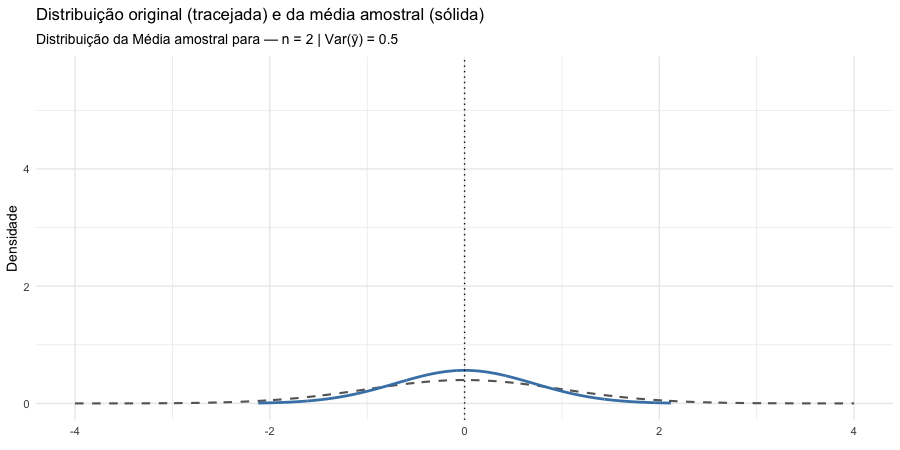

- Temos uma função de um conjunto de variáveis aleatórias que compartilham uma média comum, e ela se torna mais concentrada em torno dessa média à medida que o tamanho do conjunto aumenta.

## Distribuição da Média Amostral

**Resultados Assintóticos**

- À medida que aumentamos o tamanho da amostra, a distribuição da média amostral revela comportamentos assintóticos fundamentais que são a base da estatística e da econometria.

#### Lei dos Grandes Números (LGN)

- Quando temos variáveis aleatórias i.i.d. com valor esperado finito, a média amostral converge para o valor esperado da população.
- Esse teorema fundamenta muitos métodos de simulação estatística, como os métodos de **Monte Carlo**, onde estimamos parâmetros populacionais por meio de médias amostrais.

#### Teorema Central do Limite (TCL)

- Mostra que, sob condições gerais, a distribuição da média amostral de VAs i.i.d. com  
  variância finita se aproxima de uma distribuição normal à medida que o tamanho da amostra aumenta.
- O TCL é um dos resultados mais importantes e úteis de toda a teoria da probabilidade, que realmente serve como fundamento para a ciência estatística.

## Lei dos Grandes Números

**O que diz a Lei dos Grandes Números?**

A **Lei dos Grandes Números (LGN)** afirma que:

> Quando temos variáveis aleatórias i.i.d. com valor esperado finito, a média amostral converge para o valor esperado da população.

Traduzindo:

> Quando repetimos um fenômeno aleatório muitas vezes de forma independente, a **média dos resultados observados** se aproxima da **média teórica ($E(X)$)** da variável aleatória de interesse.

#### Formulação Matemática

Se $X_1, X_2, \dots, X_n$ são variáveis aleatórias i.i.d. com valor esperado $\mu =E[X_i]$ e $V(X_i) < \infty$, então:

$$\bar{X}_n = \frac{1}{n}\sum_{i=1}^{n} X_i
\;\xrightarrow[\;n\to\infty\;]{\;p\;}\;
\mu
\quad\text{(LGN fraca)}$$

Isso significa: **a média amostral converge (em probabilidade) para a média populacional**.

#### Exemplo

- Imagine jogar uma moeda honesta milhares de vezes. A proporção de “caras” pode oscilar no começo, mas **com o tempo ela estabiliza perto de 0.5**.
- A LGN garante esse comportamento para qualquer experimento aleatório com média finita.

#### Exemplo em R

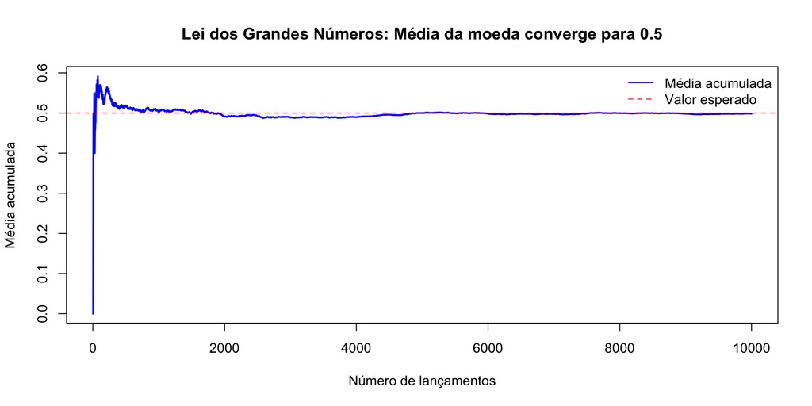

```r
# Simulando 10.000 lançamentos de moeda (0 = coroa, 1 = cara)
set.seed(42)
lancamentos <- sample(0:1, size = 10000, replace = TRUE)

# Média acumulada
media_acumulada <- cumsum(lancamentos) / (1:10000)

# Gráfico
plot(media_acumulada, type = "l", col = "blue", lwd = 2,
     main = "Lei dos Grandes Números: Média da moeda converge para 0.5",
     xlab = "Número de lançamentos", ylab = "Média acumulada")
abline(h = 0.5, col = "red", lty = 2)
legend("topright", legend = c("Média acumulada", "Valor esperado"),
       col = c("blue", "red"), lty = c(1, 2), bty = "n")
```

#### Por que isso importa?

- **Fundamenta os métodos de Simulação de Monte Carlo**: estimativas pela média amostral:

$$\hat\mu_n=\frac{1}{n}\sum_{i=1}^n g(X_i)
\;\xrightarrow[\;n\to\infty\;]{\;p\;}\;
\mathbb E[g(X)],$$

- **O que diz a fórmula:** se você **repete um experimento muitas vezes**, calcula um número em cada repetição (o $g(X_i)$) e **faz a média** desses números, **essa média vai ficando cada vez mais próxima do valor verdadeiro** que queremos ($\mathbb E[g(X)]$).
- **Tradução para Monte Carlo:** para estimar algo difícil de calcular diretamente, **simulamos muitos cenários**, computamos $g$ em cada um e **calculamos a média** — essa média é um **bom palpite** e **melhora quanto mais repetições** usamos.

## Teorema Central do Limite

**Versão de Lindebergh-lévy**

Se $X_1,\ldots,X_n$ é uma sequência de variáveis aleatórias independentes com distribuição de probabilidade arbitrária com $E(X) = \mu$ e variância finita $\sigma_{i}^2 < \infty$, então:

$$\frac{\bar X - \mu}{\sigma/\sqrt n}
= \frac{\sqrt n\,(\bar X - \mu)}{\sigma}
\xrightarrow{d} N(0,1) \quad (n \to \infty)$$

- $d$ representa *convergência em distribuição*
- O TCL é um dos resultados mais poderosos e misteriosos da teoria da probabilidade e da estatística.
- Ele mostra que o simples processo de tomar médias induz a normalidade.
- Você pode ter qualquer tipo de distribuição maluca, quase degenerada, a média amostral desta distribuição terá distribuição aproximadamente normal.
- Não precisamos conhecer a distribuição que estamos amostrando para saber muito sobre o comportamento da média amostral desta distribuição.
- O TCL é a base para os métodos de inferência estatística (estimação, testes de hipóteses e intervalos de confiança) para a maioria dos estimadores econométricos.

## Teorema Central do Limite (TCL)

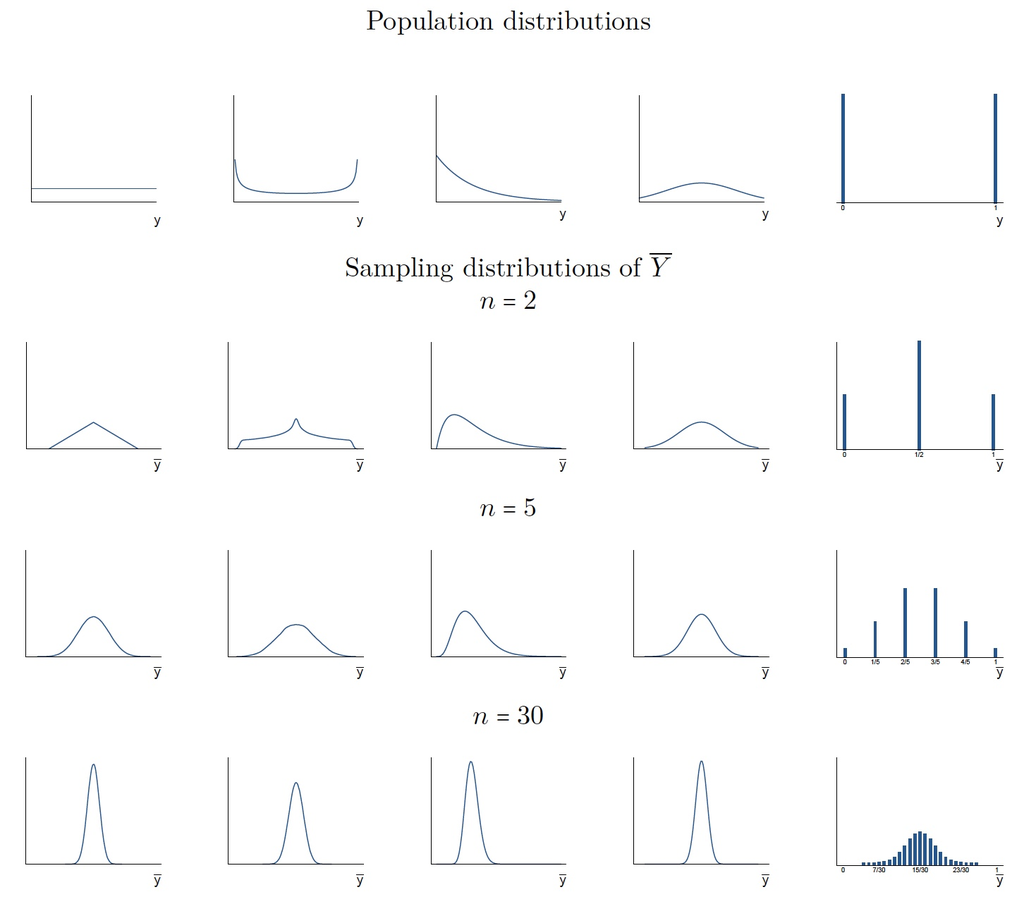

Independente da forma da distribuição original, à medida que $n$ aumenta, a distribuição de $\bar{Y}$ converge para uma distribuição normal

## Referências

BILLINGSLEY, P. **[Probability and Measure](https://www.wiley.com/en-us/Probability%2Band%2BMeasure%2C%2BAnniversary%2BEdition-p-9781118122372)**. Anniversary Edition ed. Hoboken, NJ: Wiley, 2012.

BLITZSTEIN, J. K.; HWANG, J. **[Introduction to Probability](https://drive.google.com/file/d/1VmkAAGOYCTORq1wxSQqy255qLJjTNvBI/edit)**. 1. ed. Boca Raton: Chapman; Hall/CRC, 2014.

JAMES, B. R. **[Probabilidade: um curso em nível intermediário](https://impa.br/books/probabilidade-um-curso-em-nivel-intermediario/)**. 5. ed. Rio de Janeiro, Brasil: IMPA, 2023. p. 296

ROSS, S. M. **A First Course in Probability**. 9th. ed. [s.l.] Pearson Education, 2015.